# Metro Mindset

# Introduction

The group at Metro Mindset consists of five New Yorkers who frequently use the MTA Subway system.

The MTA has been through it over the years, and especially with the COVID pandemic in 2020 where ridership plummeted.

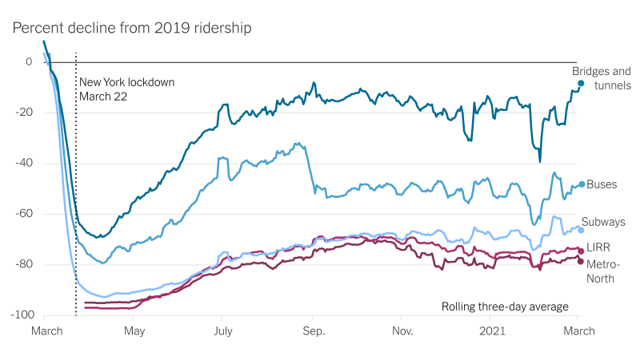

Source: New York Times

As concerned New Yorkers we ask, how is this Subway system we rely on doing?

# Motivating Question

Is the MTA NYC Subway overall better, worse, or about the same as they were pre-pandemic?

# Three R’s

We researched three categories to analyze this question:

*Ridership*:

- How many commuters are on the MTA?
- Are other forms of transit taking over?
  - Cars
  - Bikes
- What’s caused the current situation?
  - Remote Work
  - Tourism

*Revenue*:

- Is the MTA collecting revenues at or close to pre-pandemic levels?
- How are transit phenomena impacting MTA revenues?
  - Pre-pandemic: for hire vehicles
  - Post-pandemic: “work-from-home” phenomena

*Reliability*

- Has ADA accessibility across boroughs and stations increased since the pandemic?
- Of the accessible subway stations, how many are fully accessible (i.e., equipped with all necessary ADA features such as elevators, ramps, tactile guides, etc.)?
- Has Crime & Safety in the system increased or decreased?

# Ridership

## Ridership over time

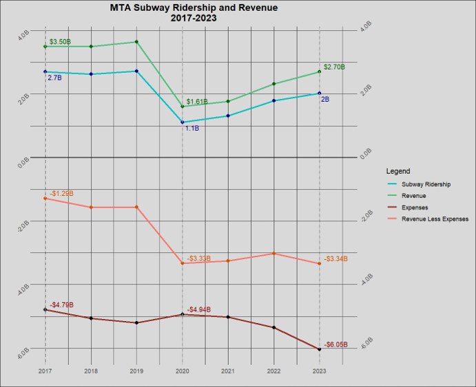

Comparing ridership and revenue in NYC

Looking at ridership over time, we see the sharp drop in ridership (and revenue) in 2020, which started at the outset of the COVID lockdowns in March 2020.

Although ridership (and by extent, revenue) are growing and are projected to reach an under-19% difference from 2019’s figures by 2028 per the *Office of the New York State Comptroller*, it still will have a way to go to recover to pre-pandemic levels of ridership.

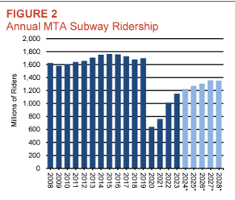

OSC NY predicts a steady increase in ridership over the coming years

It is interesting to note that home occupied homes have actually grown in this time period:

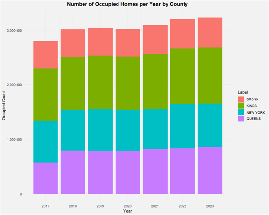

Occupied homes per year in NYC

So, while more units are becoming occupied in the city, Subway travel is still quite down.

## Other modes of transit

Because of this decline in ridership combined with an uptick in living here, we looked at how other forms of transit have done in NYC since COVID, specifically vehicle ownership and bike travel.

The working theory going into this was “are people just driving or biking more?”

During COVID, one of the many items to find their demand skyrocket were used cars.

Here’s a [news report from ABC 7 NY](https://abc7ny.com/used-cars-consumer-reports-pandemic-auto-sales-covid/8949214/?utm_source=chatgpt.com) at the time, for example.

So, did the number of cars in NYC increase that much?

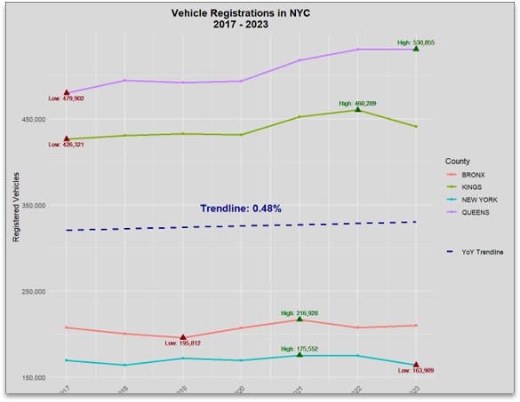

Vehicle registrations in NYC

This graph shows that while yes, vehicle ownership did increase in at least 3 of the 4 boroughs of interest in this time frame, it’s not a significant enough margin to really explain the dip in ridership on the Subway.

The other form of transit reviewed was biking.

According to one source ([NYC DOT on NYC Open Data](https://data.cityofnewyork.us/Transportation/Bicycle-Counts/uczf-rk3c/about_data)), biking seems to be down in the city, at least at the popularly monitored locations of the DOT.

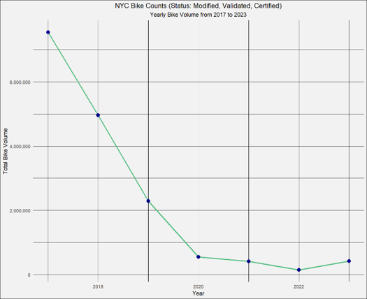

Bike ridership data tracked across several locations in NYC

## What else?

Possible explanations for what might be causing the slow-return to pre-pandemic ridership levels could be due to the surge in remote-work and a sharp decline in tourism.

We [found analysis](https://projects.thecity.nyc/hows-new-york-city-doing/index.html#subway-ridership) from a newspaper *The City* that seemed to reflect this thinking, though we’ll be discussing remote-work further down as well.

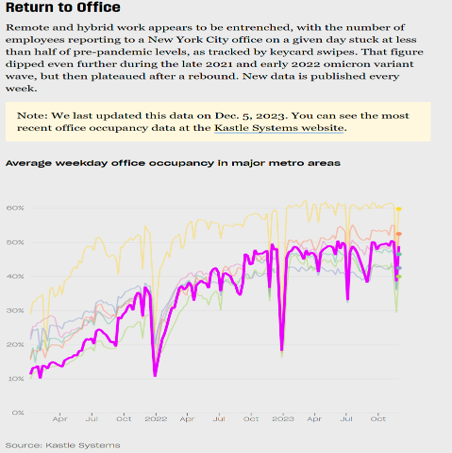

Work From Home Rates in NYC per *The City*

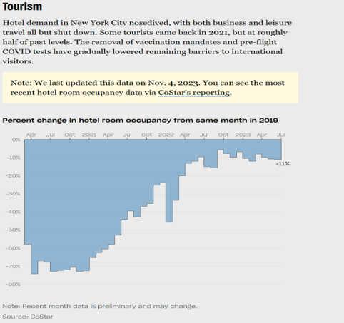

*The City*’s tourism rates based on hotel occupancies in NYC

Ridership’s slow recovery combined with the MTA’s ever-growing expenses does show a somber tale for the MTA. Fortunately (as discussed below), through funding through projects such as The Capital Program, the MTA will remain funded and growing for the foreseeable future.

# Revenue

How has the MTA’s Fare-Revenue changed?

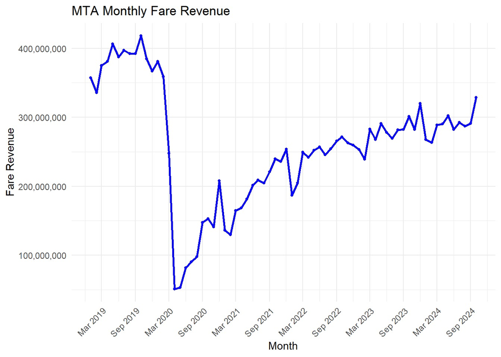

MTA Fare Revenue 2019 - 2024

## Revenue Change Over Time

The MTA’s revenue, which relies heavily on Subway and Bus fares, took a significant hit during the COVID-19 pandemic. As ridership plummeted, the MTA’s monthly fare revenue saw a sharp drop starting in March 2020, as evidenced by the sharp drop in revenue in the graph above . However, as also shown in the graph above, since March 2021 the MTA’s fare revenue has been slowly but steadily recovering. Despite this gradual improvement, we can also see that fare revenue has yet to return to pre-pandemic levels. This slow recovery raises questions about two potential hindering factors: the impact of increased use of for-hire vehicle services and the ongoing trend of “work from home,” which may be limiting the return of daily commuters – and thus fare revenue – to the MTA’s.

### Have For Hire Vehicles (FHVs) Affected the MTA’s Fare Revenue?

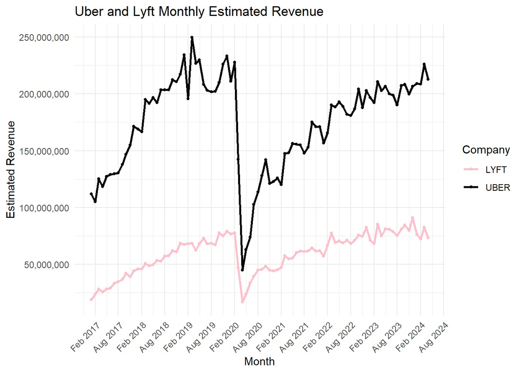

Rideshare Revenue 2017 - 2024

As demonstrated by the graph above, before 2020, For-Hire Vehicle (FHV) revenues in New York City were on a rapid, consistent growth trajectory, reflecting an increasing demand for ride-sharing services. However, with the onset of the COVID-19 pandemic, FHV revenues saw a sharp decline as citywide movement slowed and demand for rides dropped significantly.

An interesting trend to note is that FHV revenue mirrors similar fluctuations in the MTA’s fare data, suggesting a correlation between the two. While it is unlikely they directly affect one another, the recovery patterns of both sectors appear to be interconnected. When analyzed together, FHV revenues and MTA fare revenue data may better serve as valuable indicators of overall movement and transportation activity within NYC, rather than dependent factors.

### How is Remote Work Affecting the MTA’s Fare Revenue?

While hard data on the exact number of NYC workers or the percentage working from home remains unavailable, the MTA has provided literature linking the “work-from-home” trend to subway ridership in 2023, which is a key factor in estimating fare revenue. According to the MTA, the pandemic has significantly shifted ridership dynamics, with discretionary travel—such as leisure trips or non-work-related travel—becoming more common, while traditional commuter travel has declined. One major contributor to this shift is the rise of telecommuting and remote work, which has reduced the frequency of the traditional five-day commute to the office.

Furthermore, as a result of increasing remote work policies, commuting patterns have changed: ridership is now highest on Tuesdays, Wednesdays, and Thursdays, reflecting the reduced need for travel earlier in the week and later in the week. Additionally, weekend subway ridership has shown a stronger recovery, with about 77% of pre-pandemic levels, compared to only 66% on weekdays. These changes highlight how the work-from-home trend has reshaped transit behavior, contributing to a slow and uneven recovery of fare revenue for the MTA, which continues to grapple with shifting commuter habits in the post-pandemic era.

## Other System Comparison

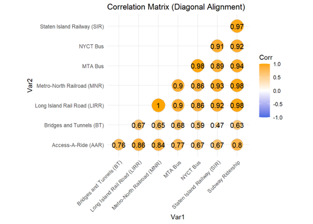

Correlation of the Subway’s ridership with other systems

Visual tools, like time series charts, correlation matrices, and distribution plots, make these patterns easy to understand. High-correlation services are integral to the MTA’s core operations, while mid- and low-correlation services cater to specialized or localized needs. These insights can help the MTA plan resources better, ensuring the transit system is responsive to the diverse needs of its riders while improving overall efficiency.

# Reliability

How has the MTA as a system fared over the past few years?

## Accessibility

The public transit system in New York City is the biggest form of transportation. However, according to the NYU Wagner publication “Making Transit Accessible for All New Yorkers”, “for roughly 13% of New York City’s population, accessing public transportation poses considerable challenges”. Before the pandemic, the MTA received increasing elevator-related complaints, regarding improper function, needing repairs, or damaged. To explore these pre-COVID concerns, we analyzed the MTA Customer Feedback Data: 2014–2019, filtering the dataset to focus on subway complaints from 2017, 2018, and 2019. I was unable to find a dataset that aligned with my vision for the analysis, so I had to manually clean the complaints data before uploading. Despite this limitation, the stacked bar chart highlighted the ongoing trend of elevator-related complaints across 2017, 2018, and 2019 and accessibility challenges faced by commuters before the pandemic.

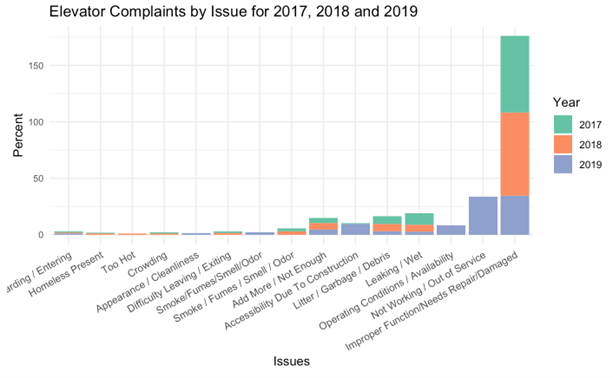

Elevator Complaints in the Subway System

During the pandemic, a historic agreement in 2020 allocated $5.2 billion from the 2020–2024 Capital Program for subway accessibility upgrades. According to the 2022 MTA press release, “ICYMI: Governor Hochul Announces MTA and Accessibility Advocates Agree on Historic Plan for Expanding Accessibility in the New York City Subway System”, this funding would make 81 stations accessible by 2025, 85 more by 2035, another 90 by 2045, and the final 90 by 2055. To evaluate accessibility progress, we used the NYC Open Data set, “MTA Subway Stations Map”, to create a map of subway lines based on accessibility. For consistency, Staten Island stations were excluded.

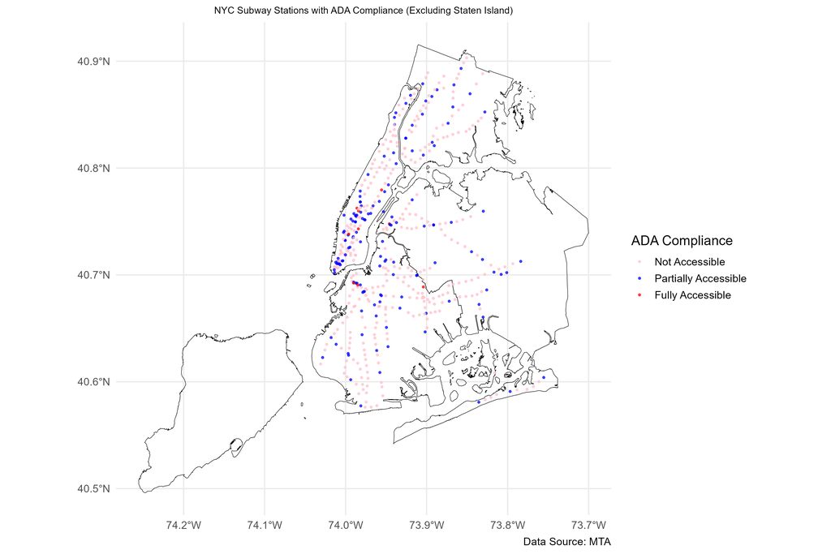

Subways with ADA Compliance in NYC excl. Staten Island

In this dataset, accessibility is represented as follows:

- 0: Not accessible
- 1: Fully accessible
- 2: Partially accessible (usually accessible in only one direction)

## Crime & Safety

The Metropolitan Transportation Authority (MTA) offers data on the count of complaints and arrests around each Precinct in our 5 boroughs. Still, we will only be focusing on the major 4 boroughs: Manhattan, Brooklyn, Queens and the Bronx. By analyzing the arrest-to-complaint ratio between the boroughs from pre-pandemic and post-pandemic we are able to determine which parts of NYC has recovered and which parts has not.

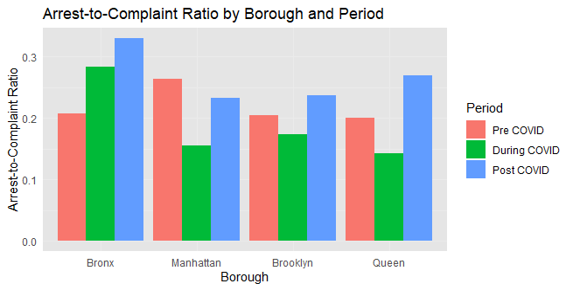

The chart here shows that the Bronx consistently has high arrest-to-complaint rates suggesting stronger enforcement or higher arrest rates relative to complaints during and post-COVID-19. Our findings align with trends discussed in a Biomedcentral article, which reported significant increases in complaints during COVID-19, particularly for assault and harassment.

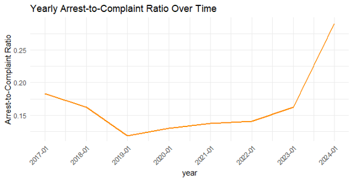

# Conclusion

Overall, the MTA has been through some rough times in recent years, though there is space for optimism.

In general, although a lot remains to be seen, the already-struggling MTA took a massive hit in 2020 and its road to recovery seems long and fraught with challenges.

Fortunately there is a lot of buy-in by both the public and various government entities to improve the system over the coming years (ie the Capital Project).